# Figure 1

Extracellular DNA promotes efficient extracellular electron transfer by pyocyanin in *Pseudomonas aeruginosa* biofilms.

Scott H. Saunders, Edmund C.M. Tse, Matthew D. Yates, Fernanda Jiménez-Otero, Jacqueline K. Barton, Leonard M. Tender and Dianne K. Newman

# Notes

Setup packages and plotting for the notebook:

```r
# Load packages
library(tidyverse)
library(cowplot)
library(kableExtra)

# Code display options
knitr::opts_chunk$set(tidy.opts=list(width.cutoff=60),tidy=FALSE, echo = TRUE, message=FALSE, warning=FALSE, fig.align="center", fig.retina = 2)

# Load plotting tools
source("../../tools/plotting_tools.R")

#Modify the plot theme
theme_set(theme_notebook())
```

# Fig. 1C - Wildtype phenazine concentrations

Read in the data - concentrations quantified from LC (Absorbance) peaks with standard curve.

# Panel D

Read in the data - concentrations quantified from LC (Absorbance) peaks with standard curve.

```r
wt_extracts <- read_csv('../../../data/LC-MS/HPLC_data_colonies_02_16_18.csv')


wt_extracts %>% kable() %>% kable_styling() %>% scroll_box(height = '250px')
```

| Name | strain | material | replicate | RT | Area | Channel Name | Amount |
| --- | --- | --- | --- | --- | --- | --- | --- |
| PYO | wt | agar | 1 | 6.233 | 48978 | 313.0nm | 2.069 |
| PCA | wt | agar | 1 | 3.726 | 200697 | 364.0nm | 13.352 |
| PCN | wt | agar | 1 | 9.071 | 478348 | 364.0nm | 31.599 |
| PYO | wt | agar | 2 | 6.226 | 43440 | 313.0nm | 1.835 |
| PCA | wt | agar | 2 | 3.685 | 150747 | 364.0nm | 10.029 |
| PCN | wt | agar | 2 | 9.065 | 419476 | 364.0nm | 27.710 |
| PYO | wt | agar | 3 | 6.243 | 41791 | 313.0nm | 1.765 |
| PCA | wt | agar | 3 | 3.678 | 145807 | 364.0nm | 9.700 |
| PCN | wt | agar | 3 | 9.073 | 390771 | 364.0nm | 25.813 |
| PYO | wt | biofilm | 1 | 6.233 | 144296 | 313.0nm | 6.095 |
| PCA | wt | biofilm | 1 | 3.804 | 18731 | 364.0nm | 1.246 |
| PCN | wt | biofilm | 1 | 9.071 | 428081 | 364.0nm | 28.278 |
| PYO | wt | biofilm | 2 | 6.236 | 133341 | 313.0nm | 5.632 |
| PCA | wt | biofilm | 2 | 3.786 | 18272 | 364.0nm | 1.216 |
| PCN | wt | biofilm | 2 | 9.064 | 408496 | 364.0nm | 26.984 |
| PYO | wt | biofilm | 3 | 6.237 | 135965 | 313.0nm | 5.743 |
| PCA | wt | biofilm | 3 | 3.772 | 18141 | 364.0nm | 1.207 |
| PCN | wt | biofilm | 3 | 9.062 | 421803 | 364.0nm | 27.863 |

```r
# Calculate concentration from Amount. For biofilm: Amount * 800 / 62, for agar: Amount * 7/5
wt_conc <- wt_extracts %>%
  mutate(phz_conc = ifelse(material=='biofilm', Amount * (800 / 62), Amount * (7 / 5)))

# Calculate the mean concentration for each group - 'Name' is the measured phenazine
# Only assign mean to first observation, because we only need one bar
wt_conc_means <- wt_conc %>%
  group_by(material, Name) %>%
  mutate(mean = ifelse(replicate==1, mean(phz_conc), NA))
```

Let’s plot the data with a fixed scale, so we can see the pattern of phenazine production by the WT cells:

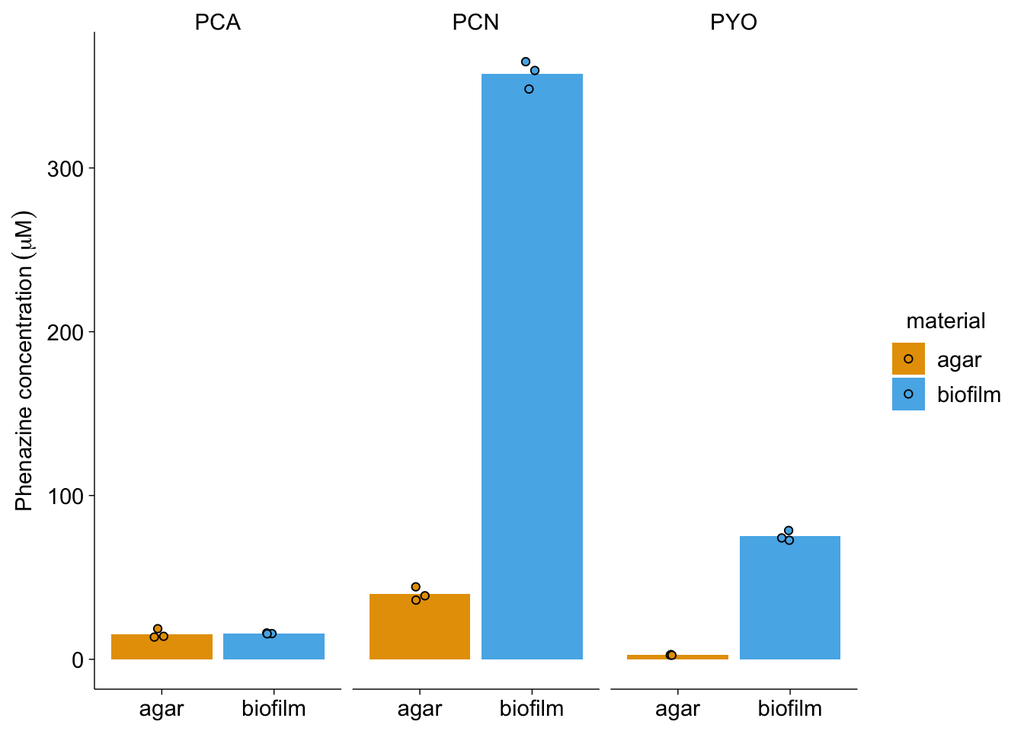

```r
#Plot layout
plot_wt_fixed <- ggplot(wt_conc_means, aes(x = material, fill = material)) +
  geom_col(aes(y = mean)) +
  geom_jitter(aes(y = phz_conc), height = 0, width = 0.1, shape = 21) +
  facet_wrap(~Name)

#Plot styling
plot_wt_fixed +
  labs(x = NULL, y = expression("Phenazine concentration" ~ ( mu*M ))) +
  theme(axis.title.x = element_text(size = 14), line = element_line(color = 'black', size = 0.25))
```

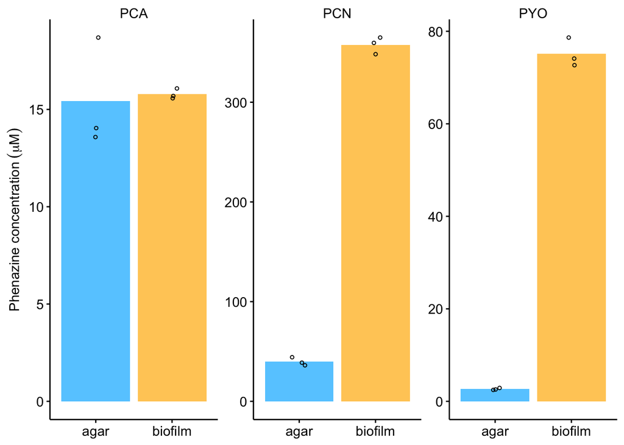

```r
#Plot layout
plot_wt_free <- ggplot(wt_conc_means, aes(x = material)) +
  geom_col(aes(y = mean, fill = material)) +
  geom_jitter(aes(y = phz_conc), height = 0, width = 0.1, shape = 21,color = 'black', size = 1) +
  facet_wrap(~Name, scales = 'free')

#Plot styling
plot_wt_free_styled <- plot_wt_free +
  labs(x = NULL, y = expression("Phenazine concentration" ~ ( mu*M ))) +
  theme(axis.title.x = element_text(size = 14)) +
  scale_fill_manual(guide = F, values = c("#66CCFF","#FFCC66"))

plot_wt_free_styled
```

ok and now this makes our point.

# Fig. 1D - WT phenazine retention ratio

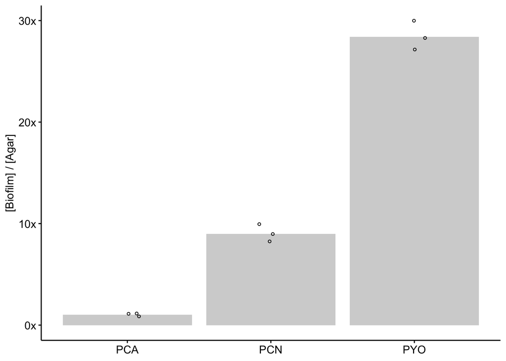

```r
# Split dataset by material
wt_conc_means_agar <- wt_conc_means %>%
  filter(material=='agar')

wt_conc_means_biofilm <- wt_conc_means %>%
  filter(material=='biofilm')

# Join agar and cell observations and calculate retention ratios = biofilm / agar
wt_conc_means_join <- left_join(wt_conc_means_biofilm, wt_conc_means_agar,
                                by = c('strain','replicate','Name'),
                                suffix = c('_from_biofilm','_from_agar')) %>%
  mutate(retention_ratio = phz_conc_from_biofilm / phz_conc_from_agar) %>%
  mutate(mean_retention_ratio = mean_from_biofilm / mean_from_agar)

# Plot Layout
wt_ret_ratio <- ggplot(wt_conc_means_join ,aes(x=Name,y=retention_ratio))+
  geom_col( aes(y = mean_retention_ratio), fill = 'light gray') +
  geom_jitter(width=0.1,height=0,shape=21,size=1)

# Plot Stlying
wt_ret_ratio_styled <- wt_ret_ratio +
  guides(fill=F) +
  scale_y_continuous(labels = fold_label) +
  labs(x = NULL, y = "[Biofilm] / [Agar]")

wt_ret_ratio_styled
```

# Fig. 1E - ∆phz* phenazine accumlation

Let’s first read in the data. This csv contains the data for multiple experiments that were run on the LC-MS on the same day, so let’s just look at the dPHZ* colonies.

```r
# Read in only the dPHZstar data, and convert the amount of phenazine added to a numeric
dphz_extracts <- read_csv('../../../data/LC-MS/2018_10_30_HPLC_concentrations_df.csv',comment = "#") %>%
  filter(strain == 'dPHZstar') %>%
  mutate(added_phz_num=as.double(str_extract(amount_added,"^[0-9.]+")))

dphz_extracts %>%
  kable() %>%
  kable_styling() %>%
  scroll_box(height = '250px')
```

| measured_phenazine | strain | amount_added | added_phenazine | material | replicate | RT | Area | Channel Name | Amount | calcConc | added_phz_num |
| --- | --- | --- | --- | --- | --- | --- | --- | --- | --- | --- | --- |
| PCA | dPHZstar | 0.1uM | PCA | cells | 1 | 3.183 | 61 | 364.0nm | 0.004 | 0.1146667 | 0.1 |
| PCN | dPHZstar | 0.1uM | PCA | cells | 1 | 8.693 | 653 | 364.0nm | 0.043 | 1.2326667 | 0.1 |
| PYO | dPHZstar | 0.1uM | PCA | cells | 1 | 5.976 | 20 | 313.0nm | 0.001 | 0.0286667 | 0.1 |
| PCA | dPHZstar | 0.1uM | PCA | cells | 2 | 3.044 | 52 | 364.0nm | 0.003 | 0.0860000 | 0.1 |
| PCN | dPHZstar | 0.1uM | PCA | cells | 2 | 8.700 | 744 | 364.0nm | 0.049 | 1.4046667 | 0.1 |
| PCA | dPHZstar | 0.1uM | PCA | cells | 3 | 3.154 | 55 | 364.0nm | 0.004 | 0.1146667 | 0.1 |
| PCN | dPHZstar | 0.1uM | PCA | cells | 3 | 8.686 | 756 | 364.0nm | 0.050 | 1.4333333 | 0.1 |
| PCA | dPHZstar | 0.1uM | PCN | cells | 1 | 2.972 | 56 | 364.0nm | 0.004 | 0.1146667 | 0.1 |
| PCN | dPHZstar | 0.1uM | PCN | cells | 1 | 8.696 | 880 | 364.0nm | 0.058 | 1.6626667 | 0.1 |
| PYO | dPHZstar | 0.1uM | PCN | cells | 1 | 6.050 | 20 | 313.0nm | 0.001 | 0.0286667 | 0.1 |
| PCA | dPHZstar | 0.1uM | PCN | cells | 2 | 3.294 | 70 | 364.0nm | 0.005 | 0.1433333 | 0.1 |
| PCN | dPHZstar | 0.1uM | PCN | cells | 2 | 8.703 | 562 | 364.0nm | 0.037 | 1.0606667 | 0.1 |
| PYO | dPHZstar | 0.1uM | PCN | cells | 2 | 5.950 | 21 | 313.0nm | 0.001 | 0.0286667 | 0.1 |
| PCA | dPHZstar | 0.1uM | PCN | cells | 3 | 2.957 | 39 | 364.0nm | 0.003 | 0.0860000 | 0.1 |
| PCN | dPHZstar | 0.1uM | PCN | cells | 3 | 8.695 | 487 | 364.0nm | 0.032 | 0.9173333 | 0.1 |
| PYO | dPHZstar | 0.1uM | PCN | cells | 3 | 5.911 | 27 | 313.0nm | 0.001 | 0.0286667 | 0.1 |
| PCA | dPHZstar | 0.1uM | PYO | cells | 1 | 3.365 | 66 | 364.0nm | 0.004 | 0.1146667 | 0.1 |
| PCN | dPHZstar | 0.1uM | PYO | cells | 1 | 8.690 | 682 | 364.0nm | 0.045 | 1.2900000 | 0.1 |
| PCA | dPHZstar | 0.1uM | PYO | cells | 2 | 3.191 | 90 | 364.0nm | 0.006 | 0.1720000 | 0.1 |
| PCN | dPHZstar | 0.1uM | PYO | cells | 2 | 8.696 | 414 | 364.0nm | 0.027 | 0.7740000 | 0.1 |
| PYO | dPHZstar | 0.1uM | PYO | cells | 2 | 6.010 | 448 | 313.0nm | 0.014 | 0.4013333 | 0.1 |
| PCA | dPHZstar | 0.1uM | PYO | cells | 3 | 3.344 | 50 | 364.0nm | 0.003 | 0.0860000 | 0.1 |
| PCN | dPHZstar | 0.1uM | PYO | cells | 3 | 8.689 | 1331 | 364.0nm | 0.088 | 2.5226667 | 0.1 |
| PYO | dPHZstar | 0.1uM | PYO | cells | 3 | 6.006 | 471 | 313.0nm | 0.014 | 0.4013333 | 0.1 |
| PCA | dPHZstar | 100uM | PCA | cells | 1 | 3.203 | 11969 | 364.0nm | 0.786 | 22.5320000 | 100.0 |
| PCN | dPHZstar | 100uM | PCA | cells | 1 | 8.699 | 1089 | 364.0nm | 0.072 | 2.0640000 | 100.0 |
| PYO | dPHZstar | 100uM | PCA | cells | 1 | 6.008 | 22 | 313.0nm | 0.001 | 0.0286667 | 100.0 |
| PCA | dPHZstar | 100uM | PCA | cells | 2 | 3.182 | 10593 | 364.0nm | 0.695 | 19.9233333 | 100.0 |
| PCN | dPHZstar | 100uM | PCA | cells | 2 | 8.689 | 752 | 364.0nm | 0.050 | 1.4333333 | 100.0 |
| PYO | dPHZstar | 100uM | PCA | cells | 2 | 5.933 | 37 | 313.0nm | 0.001 | 0.0286667 | 100.0 |

[output cut: 123 more lines]

You can see that I’ve already calculated the biofilm concentrations for this dataset. You can also see that each colony was recorded with the amount of synthetic phenazine added to the agar. Let’s calculate means for each group and look at an overview of the measurements.

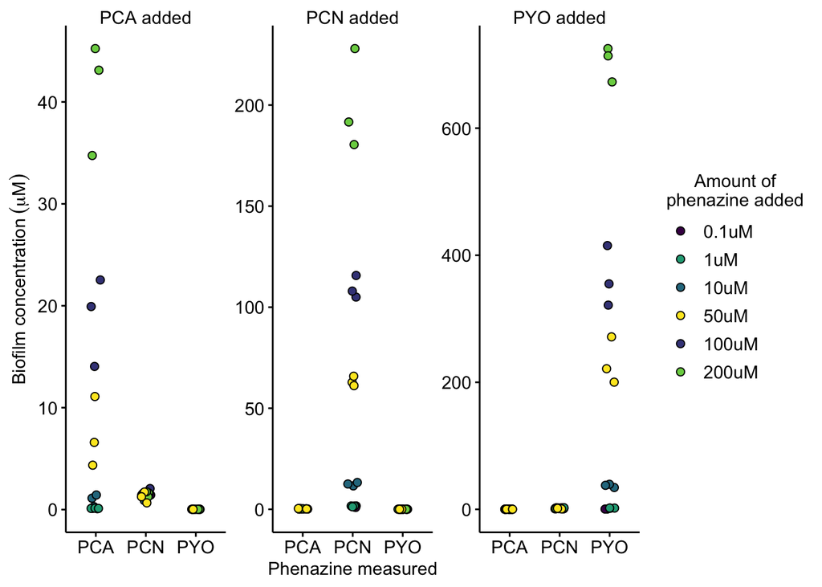

```r
# Names for facet panels
facet_labels = c(PCA = "PCA added", PCN = "PCN added", PYO = "PYO added")

# Plot layout
plot_dphz_overview <- ggplot(dphz_extracts, aes(x = measured_phenazine, y = calcConc, fill = amount_added)) +
  geom_jitter(shape = 21, height = 0, width = 0.1, size = 2)+
  facet_wrap(~added_phenazine, scale = 'free', labeller = labeller(added_phenazine = facet_labels))

# Plot styling
plot_dphz_overview +
  scale_fill_viridis(discrete = T, breaks = c('0.1uM','1uM','10uM','50uM','100uM','200uM')) +
  labs(fill = "Amount of\nphenazine added" ,
       x = "Phenazine measured",
       y = expression("Biofilm concentration" ~ ( mu*M )) )
```

Ok, so we can see that when we add a phenazine to this strain, we only measure significant amounts of that phenazine. Therefore, this mutant is “phenazine inert.” There is a little bit of PCN detected, but upon inspection of the chromatograms and MS, it is a persistent background peak that is not actually PCN.

So, let’s proceed and just look at the measured phenazines that match the added phenazine, and we’ll calculate some means.

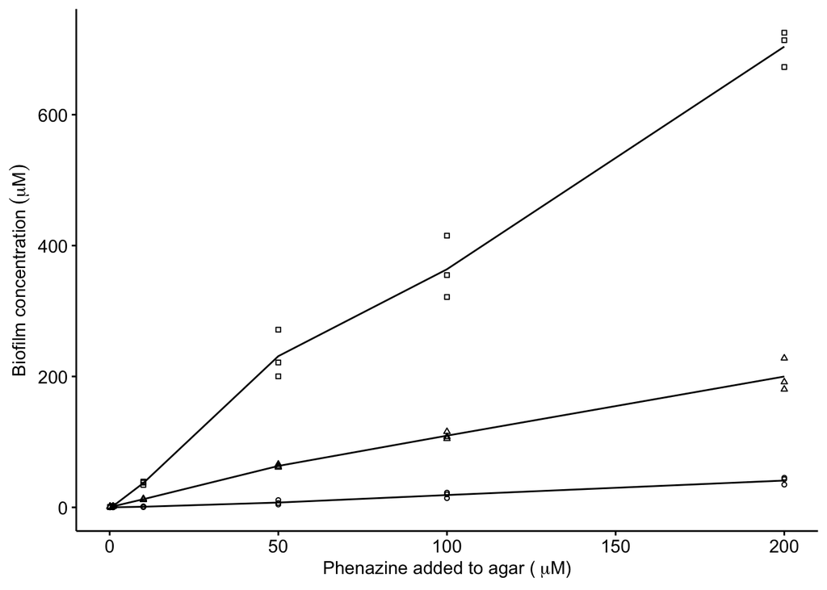

```r
# Calculate Means
dphz_extracts_means <- dphz_extracts %>%
  filter(measured_phenazine==added_phenazine) %>%
  group_by(measured_phenazine,amount_added) %>%
  mutate(mean = mean(calcConc))


# Plot layout
plot_dphz_binding <- ggplot(dphz_extracts_means, aes(x=added_phz_num,y=calcConc))+
  geom_line(size=0.5, aes(y=mean,color=measured_phenazine))+
  geom_point(size=1, shape = 21, aes(fill=measured_phenazine))

plot_dphz_binding <- ggplot(dphz_extracts_means, aes(x=added_phz_num,y=calcConc))+
  geom_line(size=0.5, aes(y=mean, group = measured_phenazine))+
  geom_point(size=1, aes(shape=measured_phenazine))

# Plot styling
plot_dphz_binding_styled <- plot_dphz_binding +
  scale_shape_discrete(solid=F, guide = F)+
  labs(x=expression('Phenazine added to agar ('~mu*"M)"),
       y = expression("Biofilm concentration" ~ ( mu*M )) ) +
  theme(legend.position = c(0.5, 0.9),
        legend.title = element_blank(),
        legend.background = element_rect(fill=NA))


#coord_fixed(ratio = 0.75)

plot_dphz_binding_styled
```

# Fig. 1F - ∆phz* phenazine retention

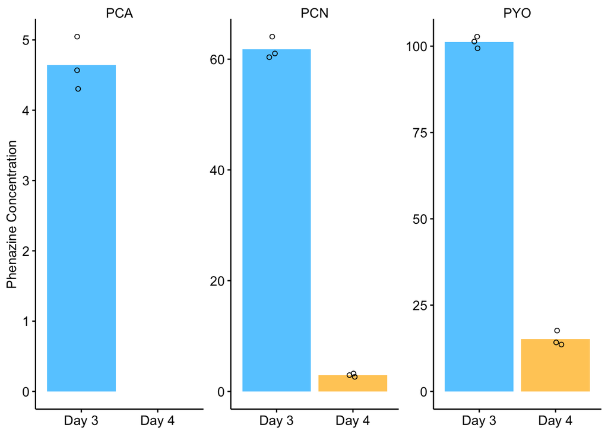

```r
pdaMan_data <- read_csv("../../../data/LC-MS/dPHZstar_PDAmanual_PHZretention_08_29_18.csv") %>%
  mutate(calcConc = Amount * 2 *(800 / 62) ) %>%
  group_by(Condition,Day,measured_phenazine) %>%
  mutate(mean = ifelse(Rep==1,mean(calcConc),NA))

dphz_ret_pdaMan_plot <- ggplot(pdaMan_data %>% filter(Condition =='PHZ'), aes(x = Day, y = calcConc, )) +
  geom_col(aes(y = mean,fill = Day))+
  geom_jitter(height = 0, width = 0.1, shape = 21) +
  facet_wrap(~measured_phenazine, scales = 'free') +
  ylim(0,NA)

#Plot styling
dphz_ret_pdaMan_plot_styled <- dphz_ret_pdaMan_plot +
  labs(x = NULL, y = "Phenazine Concentration") +
  theme(axis.title.x = element_text(size = 14)) +
  scale_fill_manual(guide = F, values = c("#66CCFF","#FFCC66")) +
  scale_x_discrete(breaks = c('D3','D4'),
                   labels=c("Day 3","Day 4"))

dphz_ret_pdaMan_plot_styled
```

For dPHZ* incubated with individual phenazines

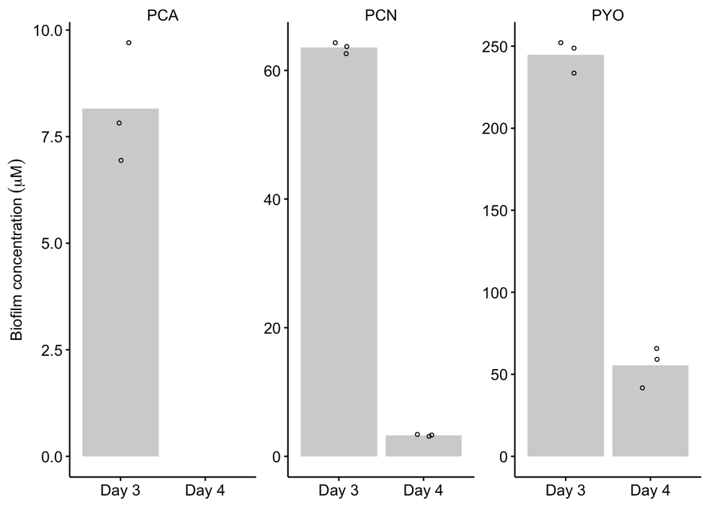

```r
pdaMan_indPhz_plot <- ggplot(pdaMan_data %>% filter(Condition == measured_phenazine), aes(x = Day, y = calcConc, )) +
  geom_col(aes(y = mean), fill='light gray')+
  geom_jitter(height = 0, width = 0.1, shape = 21, size = 1) +
  facet_wrap(~measured_phenazine, scales = 'free') +
  ylim(0,NA)

#Plot styling
pdaMan_indPhz_plot_styled <- pdaMan_indPhz_plot +
  labs(x = NULL, y = expression("Biofilm concentration" ~ (mu*M ))) +
  theme(axis.title.x = element_text(size = 14)) +
  scale_fill_manual(guide = F, values = c("#66CCFF","#FFCC66")) +
  scale_x_discrete(breaks = c('D3','D4'), labels=c("Day 3","Day 4"))

pdaMan_indPhz_plot_styled
```

# Create Fig. 1

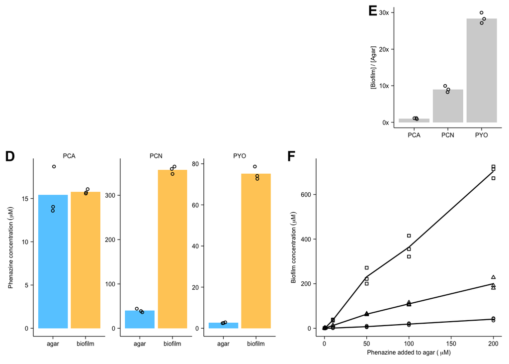

```r
theme_set(theme_figure())

top_panel <- plot_grid(NULL, wt_ret_ratio_styled, ncol = 2, rel_widths = c(2.5,1), scale = 1.0, labels = c('',"E"))

bottom_panel <- plot_grid(plot_wt_free_styled, plot_dphz_binding_styled,
                   ncol = 2,
                   align = 'hv', axis = 'tblr',
                   rel_widths = c(1.25,1),
                   scale = 1, labels = c("D", "F"))

fig_1 <- plot_grid(top_panel, bottom_panel, ncol = 1, rel_heights = c(1,1.5))

fig_1
```

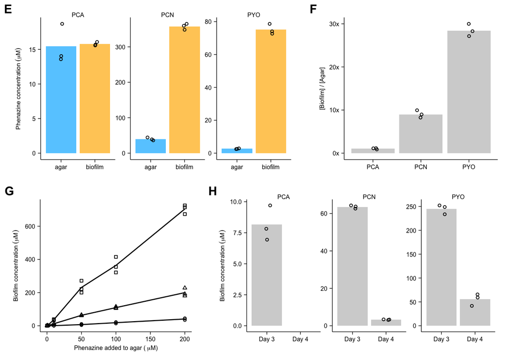

```r
top_panel <- plot_grid(plot_wt_free_styled,wt_ret_ratio_styled, ncol = 2, rel_widths = c(1.5,1), scale = 0.95, labels = c('E',"F"), align = 'hv', axis = 'tblr',label_size = 12)

bottom_panel <- plot_grid(plot_dphz_binding_styled, pdaMan_indPhz_plot_styled, ncol = 2, rel_widths = c(1,1.5), scale = 0.95, labels = c('G',"H"), align = 'hv', axis = 'tblr',label_size = 12)

fig_1 <- plot_grid(plot_wt_free_styled,wt_ret_ratio_styled, plot_dphz_binding_styled, pdaMan_indPhz_plot_styled, ncol = 2, rel_heights = c(1,1), rel_widths = c(1,1), align = 'hv', axis = 'tblr')

fig_1 <- plot_grid(top_panel, bottom_panel, ncol = 1)

fig_1
```

```r
#save_plot("../figures/02_12_19_fig_1_draft_2.pdf", fig_1, base_width = 8.5, base_height = 6)

save_plot("../../../figures/phz2019_Fig_1.pdf", fig_1, base_width = 3.42, base_height = 3)
```